# Generating Random Variates from a Truncated Gamma Distribution Using Python

Author

Wade K. Copeland

Published

February 01, 2026

# 1 Truncated Gamma Distribution

A continuous random variable $X \sim GAM(\alpha, \theta)$ if it has a probability density function (PDF) of the form in Equation 1 [(Bain and Engelhardt 1992, 4:111)].

$$\begin{aligned}
f(x|\alpha, \theta) = \frac{x^{\alpha-1}e^{-x/\theta}}{\theta^\alpha \Gamma(\alpha)} \text{ } \text{ for } x, \alpha, \theta > 0 \text{ with } \\
\Gamma(\alpha) = \int_{0}^{\infty} t^{\alpha - 1}e^{-t} dt
\end{aligned}
\tag{1}$$

For this PDF the cumulative distribution function (CDF) (a.k.a, Regularized Lower Incomplete Gamma Function) is shown in Equation 2 [(Bain and Engelhardt 1992, 4:112)].

$$F(x|\alpha, \theta) = \int_{0}^x f(u|\alpha, \theta) du = \frac{\gamma(\alpha, \frac{x}{\theta})}{\Gamma(\alpha)} \text { with } \gamma(\alpha, \frac{x}{\theta}) = \int_{0}^{x/\theta} t^{\alpha - 1}e^{-t} dt
\tag{2}$$

The support of $x$ is $[0, \infty)$, so to create a truncated distribution we need to restrict this support to the interval $[A, B]$ with $0 \le A < B$. This implies the following truncated PDF in Equation 3 (e.g., $\int_{A}^{B} f_T(x)dx = 1$).

$$f_T(x|\alpha, \theta) = \frac{f(x)}{F(B|\alpha, \theta) - F(A|\alpha, \theta)} \text{ } \forall x \in [A, B]
\tag{3}$$

For the truncated gamma distribution the first two moments are shown in Equation 4 and Equation 5. Detailed derivations for each of these moments can be found in Appendix 3.1. With the first two moments in hand, the variance follows immediately since $Var[X] = E[X^2] - (E[X])^2$ [(Bain and Engelhardt 1992, 4:74)].

$$E[X|A \le X \le B] = \frac{\int_{A}^{B} xf(x)dx}{\int_{A}^{B} f(x)dx} = \theta \alpha \frac{F(B|\alpha + 1, \theta) - F(A|\alpha + 1, \theta)}{F(B|\alpha, \theta) - F(A|\alpha, \theta)}
\tag{4}$$

$$E[X^2|A \le X \le B] = \frac{\int_{A}^{B} x^2f(x)dx}{\int_{A}^{B} f(x)dx} = \theta^2(\alpha + 1)\alpha \frac{F(B|\alpha+2, \theta) - F(A|\alpha + 2, \theta)}{F(B|\alpha, \theta) - F(A|\alpha, \theta)}
\tag{5}$$

# 2 Example

Suppose we want to generate 100,000 random variates from a **gamma distribution truncated to the interval** [0, 1000], where the mean is 100 and the standard deviation is 1/2 the value of the mean (e.g., the coefficient of variation).

We can accomplish this in Python using the **`truncated_gamma_rvs`** python package [(Copeland 2026)]. From this module, the function **`truncgamma_rvs`** generates random variates from a truncated gamma distribution. It accepts the following arguments:

- **`mean_target`**: Target mean of the truncated gamma distribution.
- **`cv_target`**: Target coefficient of variation of the truncated gamma distribution.
- **`A`**: Lower bound of the truncated gamma distribution.
- **`B`**: Upper bound of the truncated gamma distribution.
- **`size`**: Number of random variates to generate.
- **`random_state`**: Seed for reproducibility.
  - Set to an integer for consistent results.
  - Set to `None` if reproducibility is not required.

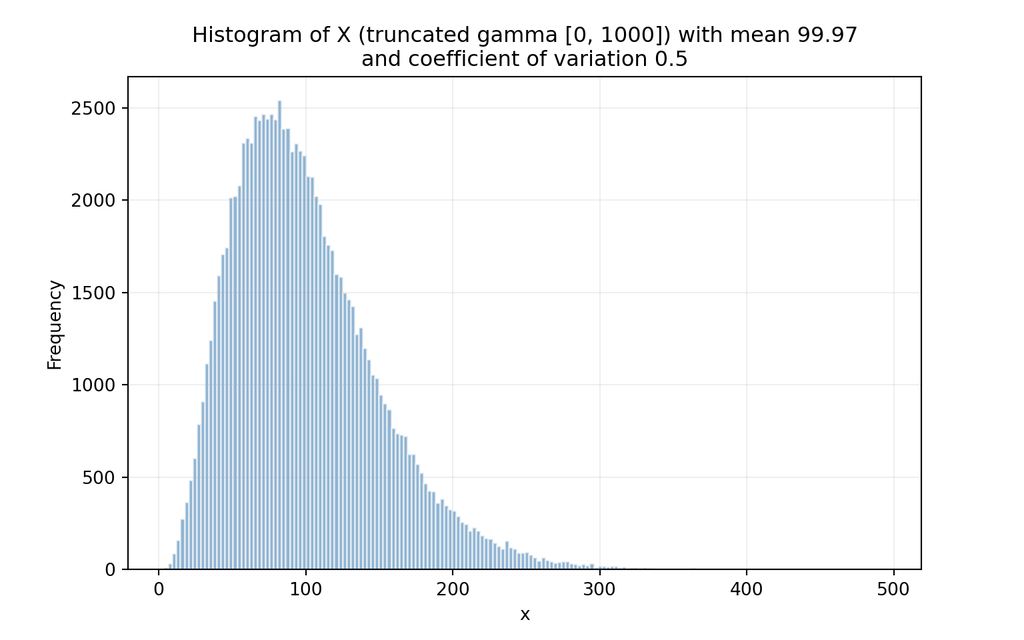

```python
from truncated_gamma_rvs import truncgamma_rvs
import matplotlib.pyplot as plt

x = truncgamma_rvs(mean_target = 100, cv_target = 1/2, A = 0, B = 1000, size = 100000, random_state = 123)

plt.figure(figsize=(8,5))
plt.hist(x, bins = "fd", density = False, alpha = 0.6, color = "steelblue", edgecolor = 'white')
plt.title(f"Histogram of X (truncated gamma [0, 1000]) with mean {round(x.mean(), 2)}\nand coefficient of variation {round(x.var()**0.5/x.mean(), 2)}")
plt.xlabel("x")
plt.ylabel("Frequency")
plt.grid(True, alpha = 0.2)
plt.show()
```

# 3 Appendicies

## 3.1 Detailed Derivations

### 3.1.1 Derivation of the Denominator for Equation 4 and Equation 5

Theorem 1 shows the derivation of the denominator for Equation 4 and Equation 5.

**Theorem 1** $\int_{A}^{B} f(x)dx = F(B|\alpha, \theta) - F(A|\alpha, \theta)$

*Proof*. $\int_{A}^{B} f(x)dx = \frac{1}{\theta^{\alpha} \Gamma(\alpha)} \int_{A}^{B} x^{\alpha-1}e^{-x/\theta}$

Let $t = \frac{x}{\theta} \implies x = t\theta$ and $\frac{dx}{dt} = \theta \implies dx = \theta dt$

Then $\int_{A}^{B} x^{\alpha-1}e^{-x/\theta} = \int_{A/\theta}^{B/\theta} (t\theta)^{\alpha-1}e^{-t}\theta dt = \theta^{\alpha} \int_{A/\theta}^{B/\theta} t^{\alpha-1}e^{-t}dt = \theta^{\alpha} \big((\int_{0}^{B/\theta} t^{\alpha-1}e^{-t}dt) - (\int_{0}^{A/\theta} t^{\alpha-1}e^{-t}dt)\big) = \theta^{\alpha} (\gamma(\alpha, \frac{B}{\theta}) - \gamma(\alpha, \frac{A}{\theta}))$

$\therefore \int_{A}^{B} f(x)dx = \frac{1}{\theta^{\alpha} \Gamma(\alpha)} (\theta^{\alpha} (\gamma(\alpha, \frac{B}{\theta}) - \gamma(\alpha, \frac{A}{\theta})) = F(B|\alpha, \theta) - F(A|\alpha, \theta)$

### 3.1.2 Derivation of the Numerator for Equation 4

Theorem 2 shows the derivation of the numerator for Equation 4.

**Theorem 2** $\int_{A}^{B} xf(x)dx = \theta \alpha (F(B|\alpha+1, \theta) - F(A|\alpha+1, \theta))$

*Proof*. $\int_{A}^{B} xf(x)dx = \frac{1}{\theta^{\alpha} \Gamma(\alpha)} \int_{A}^{B} x^1 x^{\alpha - 1}e^{-x/\theta} = \frac{1}{\theta^{\alpha} \Gamma(\alpha)} \int_{A}^{B} x^{\alpha}e^{-x/\theta}$

Let $t = \frac{x}{\theta} \implies x = t\theta$ and $\frac{dx}{dt} = \theta \implies dx = \theta dt$

Then $\int_{A}^{B} x^{\alpha}e^{-x/\theta} = \int_{A/\theta}^{B/\theta} (t\theta)^{\alpha}e^{-t} \theta dt = \theta^{\alpha + 1} \int_{A/\theta}^{B/\theta} t^{\alpha} e^{-t} dt = \theta^{\alpha + 1} (\gamma(\alpha + 1, \frac{B}{\theta}) - \gamma(\alpha + 1, \frac{A}{\theta}))$

Substituting this integral into the original equation we have,

$\int_{A}^{B} xf(x)dx = \frac{1}{\theta^{\alpha} \Gamma(\alpha)} \theta^{\alpha + 1} (\gamma(\alpha + 1, \frac{B}{\theta}) - \gamma(\alpha + 1, \frac{A}{\theta})) = \theta \frac{\gamma(\alpha + 1, \frac{B}{\theta}) - \gamma(\alpha + 1, \frac{A}{\theta})}{\Gamma(\alpha)}$

Note $\Gamma(\alpha + 1) = \alpha \Gamma(\alpha)$ [(Bain and Engelhardt 1992, 4:111)].

$\therefore \int_{A}^{B} xf(x)dx = \theta \frac{\gamma(\alpha + 1, \frac{B}{\theta}) - \gamma(\alpha + 1, \frac{A}{\theta})}{\Gamma(\alpha)} = \theta \frac{\gamma(\alpha + 1, \frac{B}{\theta}) - \gamma(\alpha + 1, \frac{A}{\theta})}{\Gamma(\alpha+1)/\alpha} = \theta \alpha (F(B|\alpha+1, \theta) - F(A|\alpha+1, \theta))$

### 3.1.3 Derivation of the Numerator for Equation 5

*Proof*. $\int_{A}^{B} x^2f(x)dx = \frac{1}{\theta^{\alpha} \Gamma(\alpha)} \int_{A}^{B} x^2 x^{\alpha - 1}e^{-x/\theta} = \frac{1}{\theta^{\alpha} \Gamma(\alpha)} \int_{A}^{B} x^{\alpha + 1}e^{-x/\theta}$

Let $t = \frac{x}{\theta} \implies x = t\theta$ and $\frac{dx}{dt} = \theta \implies dx = \theta dt$

Then $\int_{A}^{B} x^{\alpha+1}e^{-x/\theta} = \int_{A/\theta}^{B/\theta} (t\theta)^{\alpha+1}e^{-t} \theta dt = \theta^{\alpha + 2} \int_{A/\theta}^{B/\theta} t^{\alpha + 1} e^{-t} dt = \theta^{\alpha + 2} (\gamma(\alpha + 2, \frac{B}{\theta}) - \gamma(\alpha + 2, \frac{A}{\theta}))$

Substituting this integral into the original equation we have,

$\int_{A}^{B} x^2f(x)dx = \frac{1}{\theta^{\alpha} \Gamma(\alpha)} \theta^{\alpha + 2} (\gamma(\alpha + 2, \frac{B}{\theta}) - \gamma(\alpha + 2, \frac{A}{\theta})) = \theta^2 \frac{\gamma(\alpha + 2, \frac{B}{\theta}) - \gamma(\alpha + 2, \frac{A}{\theta})}{\Gamma(\alpha)}$

Note $\Gamma(\alpha + 2) = (\alpha+1) \alpha \Gamma(\alpha)$ [(Bain and Engelhardt 1992, 4:111)].

$\therefore \int_{A}^{B} x^2f(x)dx = \theta^2 \frac{\gamma(\alpha + 2, \frac{B}{\theta}) - \gamma(\alpha + 2, \frac{A}{\theta})}{\Gamma(\alpha+2)/(\alpha + 1)\alpha} = \theta^2(\alpha + 1)\alpha (F(B|\alpha + 2, \theta) - F(A|\alpha + 2, \theta))$

## 3.2 Session Information

All of the files needed to reproduce these results can be downloaded from the Git repository https://github.com/wkingc/truncated-gamma-rvs-py.

```
-----
matplotlib          3.10.8
session_info        v1.0.1
truncated_gamma_rvs 0.1.6
-----
Python 3.14.2 (main, Dec  5 2025, 16:49:16) [Clang 17.0.0 (clang-1700.6.3.2)]
macOS-26.2-arm64-arm-64bit-Mach-O
-----
Session information updated at 2026-02-01 15:55
```

## 4 References

Bain, Lee J, and Max Engelhardt. 1992. *Introduction to Probability and Mathematical Statistics*. Vol. 4. Duxbury Press Belmont, CA.

Copeland, Wade K. 2026. “truncated-gamma-rvs: A Python package for generating random variates from a truncated gamma distribution.” https://pypi.org/project/truncated-gamma-rvs/.